# MLProject-3

```
346/346 - 4s - loss: 0.3277 - accuracy: 0.8702 - val_loss: 0.2883 - val_accuracy: 0.8694 - 4s/epoch - 12ms/step
346/346 - 3s - loss: 0.3256 - accuracy: 0.8692 - val_loss: 0.2884 - val_accuracy: 0.8702 - 3s/epoch - 8ms/step
346/346 - 3s - loss: 0.3203 - accuracy: 0.8741 - val_loss: 0.2913 - val_accuracy: 0.8697 - 3s/epoch - 8ms/step
346/346 - 3s - loss: 0.3245 - accuracy: 0.8715 - val_loss: 0.2965 - val_accuracy: 0.8578 - 3s/epoch - 8ms/step
346/346 - 2s - loss: 0.3226 - accuracy: 0.8704 - val_loss: 0.2845 - val_accuracy: 0.8689 - 2s/epoch - 7ms/step
346/346 - 2s - loss: 0.3228 - accuracy: 0.8701 - val_loss: 0.2810 - val_accuracy: 0.8694 - 2s/epoch - 5ms/step
346/346 - 2s - loss: 0.3220 - accuracy: 0.8712 - val_loss: 0.2888 - val_accuracy: 0.8670 - 2s/epoch - 5ms/step
346/346 - 1s - loss: 0.3193 - accuracy: 0.8741 - val_loss: 0.2912 - val_accuracy: 0.8692 - 1s/epoch - 4ms/step
346/346 - 1s - loss: 0.3224 - accuracy: 0.8709 - val_loss: 0.2860 - val_accuracy: 0.8697 - 1s/epoch - 4ms/step
346/346 - 2s - loss: 0.3225 - accuracy: 0.8709 - val_loss: 0.2834 - val_accuracy: 0.8681 - 2s/epoch - 4ms/step
Restoring model weights from the end of the best epoch: 6.
346/346 - 2s - loss: 0.3166 - accuracy: 0.8734 - val_loss: 0.2812 - val_accuracy: 0.8729 - 2s/epoch - 5ms/step
Epoch 00011: early stopping
-----------------------------------------

Name model:  neural network
-----------------------------------------

 Training Accuracy [0.2696745991706848, 0.8801992535591125]
 Test Accuracy [0.2810148000717163, 0.8694241642951965]
True Negatives : 0
True Positives : 3116
False Negative : 0  (Type II error)
False Positives : 583  (Type I error)
correctly predicted : 3116
miss-classified : 583
auc : 0.5
```

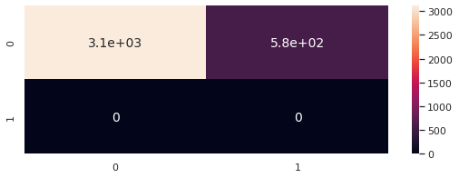

```python
model("neural network",model2,save=False)
```

**KMeans**

```
[0.54254843 0.10405705]
```

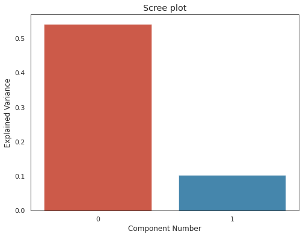

```python
n_components=2

pca = PCA(n_components=n_components)
pca.fit(x_train)
new_data = pca.transform(x_train)
print(pca.explained_variance_ratio_)
# Do a scree plot
ind = np.arange(0, n_components)
(fig, ax) = plt.subplots(figsize=(8, 6))
sns.barplot(x=ind, y=pca.explained_variance_ratio_)
ax.set_title('Scree plot')
ax.set_xticks(ind)
ax.set_xticklabels(ind)
ax.set_xlabel('Component Number')
ax.set_ylabel('Explained Variance')
plt.show()
```

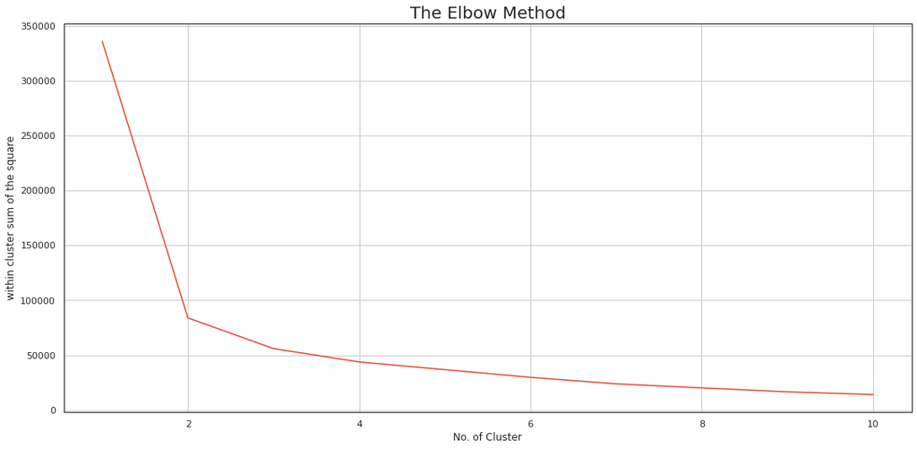

```python
def wcss_(x):

  wcss = []

  for i in range(1,11):
    km = KMeans(n_clusters=i,init='k-means++', max_iter=500, n_init=3, random_state=0)
    km.fit(x)
    labels = km.labels_
    wcss.append(km.inertia_)

  plt.rcParams['figure.figsize'] = (15, 7)
  plt.plot(range(1, 11), wcss)
  plt.grid()
  plt.tight_layout()
  plt.title('The Elbow Method', fontsize = 20)
  plt.xlabel('No. of Cluster')
  plt.ylabel('within cluster sum of the square')
  plt.show()

wcss_(new_data)
```

According to the elbow rule, it is clear that the optimal number of clusters to choose is 2.

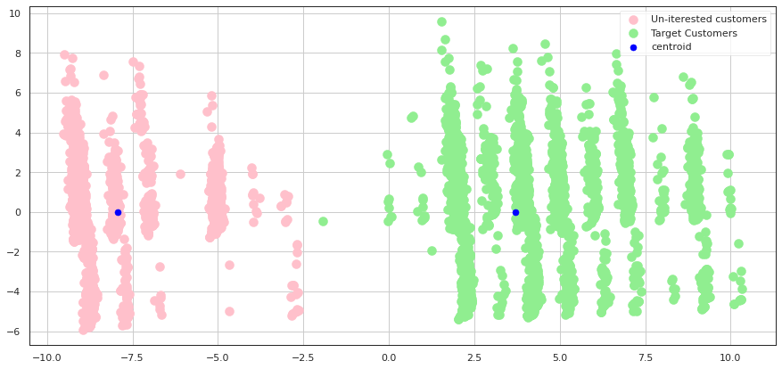

```python
km = KMeans(n_clusters=2,init='k-means++', max_iter=500, n_init=3, random_state=0)


y_means = km.fit_predict(new_data)

plt.scatter(new_data[y_means == 0,0], new_data[y_means == 0, 1], s = 100, c = 'pink', label = 'Un-iterested customers')
plt.scatter(new_data[y_means == 1, 0], new_data[y_means == 1, 1], s = 100, c = 'lightgreen', label = 'Target Customers')
#plt.scatter(new_data[y_means == 2, 0], new_data[y_means == 2, 1], s = 100, c = 'red', label = 'Other Customers')

plt.scatter(km.cluster_centers_[:, 0], km.cluster_centers_[:, 1], s = 50, c = 'blue', label = 'centroid')

#plt.title('Region vs Traffic Type', fontsize = 20)
# plt.xlabel('Region')
# plt.ylabel('Traffic')
plt.legend()
plt.grid()
plt.show()
```

```python
from keras.utils.metrics_utils import ConfusionMatrix
k_labels = km.labels_  # Get cluster labels
k_labels_matched = np.empty_like(k_labels)

# For each cluster label...
for k in np.unique(k_labels):

    # ...find and assign the best-matching truth label
    match_nums = [np.sum((k_labels==k)*(y_train==t)) for t in np.unique(y_train)]
    k_labels_matched[k_labels==k] = np.unique(y_train)[np.argmax(match_nums)]

correct_labels = sum(y_train== k_labels)
print("Accuracy score on train data :",round(accuracy_score(y_train,k_labels),2))
```

```
Accuracy score on train data : 0.4
```

Accuracy score on train data is very wrong.

```python
model("KNN",km)
```

[output not shown]

We will not try to tuner this model since without it it is already worse in forecast than simple models such as logistic regression.

**Bayesian Gaussian Mixture**

```
-----------------------------------------

Name model:  Mixture
-----------------------------------------

Training Accuracy:  -12.032438062629291
Testing Accuracy:  -11.744810736596415
Accuray_score:  0.745066234117329
True Negatives : 514
True Positives : 2242
False Negative : 69  (Type II error)
False Positives : 874  (Type I error)
correctly predicted : 2756
miss-classified : 943
auc : 0.8005794251767561
```

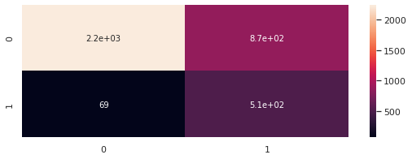

```python
model("Mixture ",BayesianGaussianMixture(n_components=2,random_state=42))
```

```python
plt.figure(figsize=(15,8))

t  = PrettyTable(["Model","accuracy","missclassification","auc"])
for i in range(len(classifier)):
  t.add_row([classifier[i],round(accuracy[i],2),round(missclassification[i],2),round(auc[i],4)])
print(t)
```

```
+-------------------------------+----------+--------------------+--------+
|             Model             | accuracy | missclassification |  auc   |
+-------------------------------+----------+--------------------+--------+
|     Support vector Machine    |   0.88   |        441         | 0.6727 |
| Support vector machine Tunned |   0.88   |        439         | 0.6695 |
|      Regression Logistic      |   0.88   |        450         | 0.6608 |
|   Logistic Regression tunned  |   0.88   |        451         | 0.6585 |
|              LDA              |   0.87   |        467         | 0.6427 |
|              QDA              |   0.85   |        539         | 0.7413 |
|              KNN              |   0.87   |        497         | 0.6428 |
|           KNN Tuned           |   0.87   |        490         | 0.6258 |
|    Random Forest classifier   |   0.9    |        375         | 0.7467 |
|      Random Forest Tunned     |   0.9    |        366         | 0.7551 |
|       Bagging classifier      |   0.9    |        376         | 0.7486 |
|   bagging classifier tunned   |   0.9    |        363         | 0.7682 |
|      ada boost classifier     |   0.89   |        417         | 0.7435 |
|   adaboost classifier Tunned  |   0.88   |        433         | 0.7353 |
|           Xgb tunned          |   0.9    |        356         | 0.7728 |
|       Gradient boosting       |   0.9    |        360         | 0.7749 |
|    gradient boosting tunned   |   0.9    |        358         | 0.7711 |
|       Gradient boosting       |   0.9    |        360         | 0.7749 |
|    Decision Tree Classifier   |   0.86   |        503         | 0.7485 |
|         neural network        |   0.84   |        583         |  0.5   |
|              KNN              |   0.41   |        2174        | 0.5626 |
|            Mixture            |   0.75   |        943         | 0.8006 |
+-------------------------------+----------+--------------------+--------+
```

As we can see, we can reach pretty good model with simple models like Logistic regression ( accuracy =0.88, missclassification =450), Decision Tree Classifier(accuracy=0.86,missclassification =503).